# Partial Least Squares

May 18, 2017

Partial Least Squares (PLS) finds a subset of a set of predictors which are uncorrelated and then runs an ordinary regression. This is useful when your data has

- a lot of collinearity
- more predictors than observations
- or when least-squares regression produces coefficients with high standard errors.

```r
rm(list = ls())
library(pls) # For plsr function
library(corrplot) # To view correlation matrix
library(caret) # to run pls
library(ggplot2) # to plot
library(ggthemes) # to plot... prettily : )
```

Let’s look at the `gasoline` dataset contained within the `pls` package. We see that there are much more predictors (401) than cases (60). Next, let’s verify that the data is highly collinear.

Here, we’re going to predict octane levels based on NIR spectra.

But first, I’m having difficulty using `caTools::sample.split` and `caret::createDataPartition` to subset the data. I believe that each of these functions assume that the number of cases is greater than the number of predictors. It is choosing the column or row that is largest and using that side for the split vector. I’m going to have to do a little more research into splitting this type of data. That means, whether I transpose the data or not, I am getting a vector of length 401, not 60. For now, we’ll randomly sample.

```r
octane = gasoline$octane # Create new variable name to make column naming easier
dataset = cbind(gasoline$NIR, octane) # bind predictors and response
nRows = 1:nrow(dataset) # columns to sample from
nSamples = 40
trainNum = sample(nRows, nSamples)
train = dataset[trainNum,]
test = dataset[-trainNum,]
```

# Collinearity

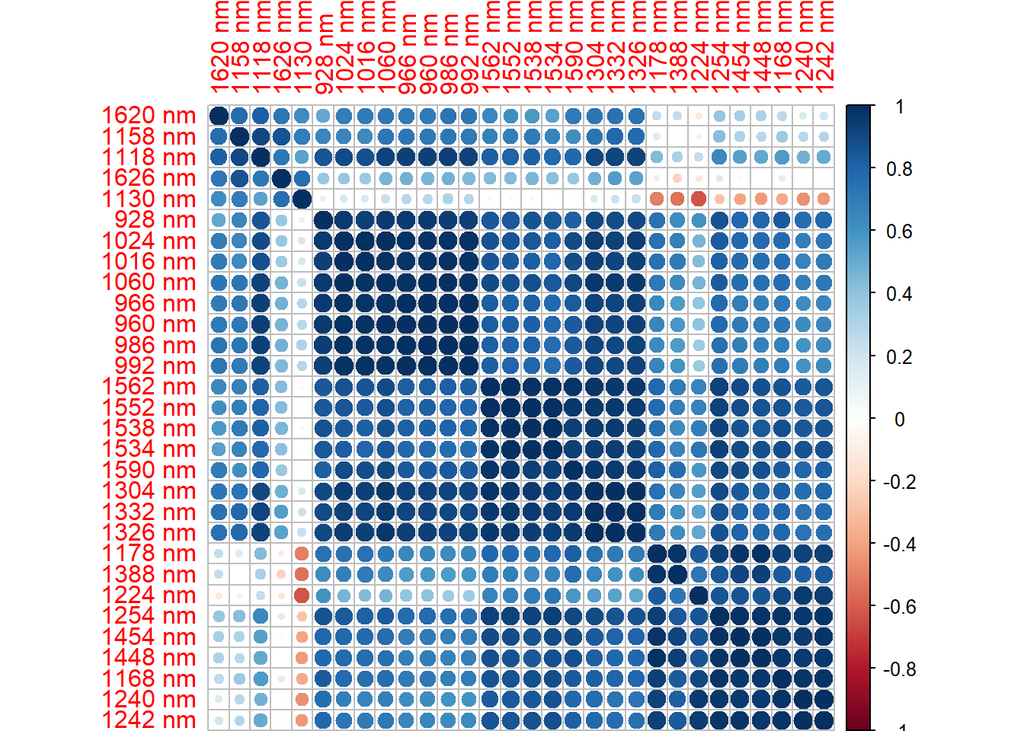

```r
trainPred = train[,-ncol(train)]

sampleCols = sample(1:ncol(train), 30, replace = FALSE)
correlation = cor(train[,sampleCols])
corrplot(correlation, order = "hclust")
```

# Train Model

Looks like the assumptions are pretty well met. Let’s run the model. The number of compontents is specified by the `ncomp` argument. Let’s make predictions using 20 components.

```r
train = as.data.frame(train)
plsFit = plsr(octane ~., data=train, ncomp = 20)
```

# Predictor Matrix

So, here we can see that we went from 401 predictors to 20. The projection matrix contains projections of the observarions on the PLS regression components. PSL regression fits the projections (x-scores), which replate the original predictors, using least squares.

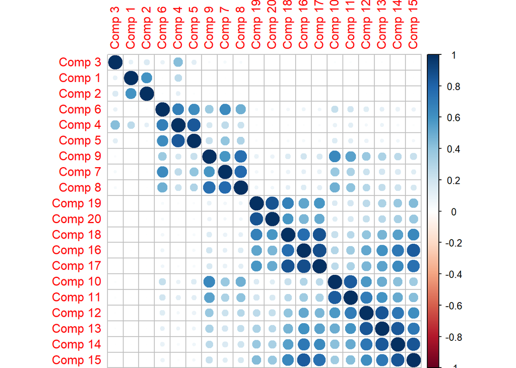

```r
correlations = cor(plsFit$projection)
corrplot(correlations, order = "hclust")
```

# Predict

```r
test = as.data.frame(test)
predictions = predict(plsFit, test, ncomp = 20)

df = data.frame(TrueValues = test$octane, PredictedValues = as.vector(predictions))
```

Now, let’s take a look at our solution.

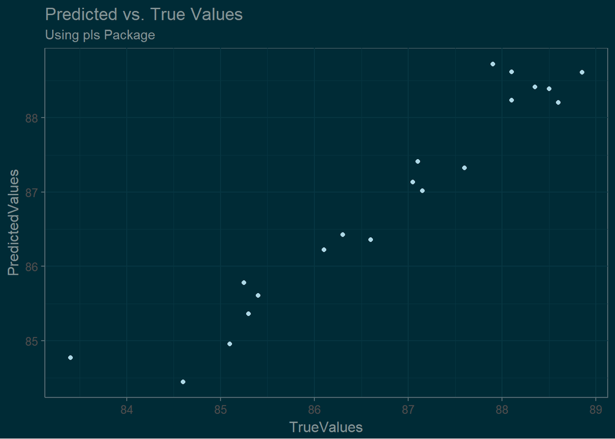

```r
ggplot(df, aes(x = TrueValues, y = PredictedValues)) +
  geom_point(col = "light blue") +
  theme_solarized(light = FALSE) +
  ggtitle("Predicted vs. True Values", sub = "Using pls Package")
```

# caret

Using `caret` we can do the same method. This time, we’ll also run the model with 10-fold cross validation.

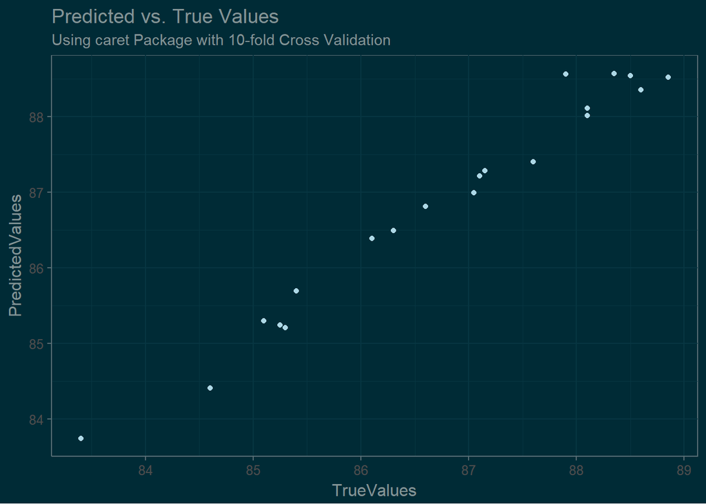

```r
trainResp = train[,ncol(train)] # extract response vector

ctrl = trainControl(method = "cv", number = 10) # State 10-fold cross validation to be used in model

plsTune = train(trainPred, trainResp,
                method = "pls", # indication of model type
                tuneLength = 20,
                trControl = ctrl, # cross validation
                preProc = c("center", "scale"))

predictions = predict(plsTune, test) # vector of predicted values

df = data.frame(TrueValues = test$octane, PredictedValues = as.vector(predictions))

ggplot(df, aes(x = TrueValues, y = PredictedValues)) +
    geom_point(col = "light blue") +
    theme_solarized(light = FALSE) +
    ggtitle("Predicted vs. True Values",
    sub = "Using caret Package with 10-fold Cross Validation")
```

So, if you’re data if ever structured in this way, you know what to do now!

Read about PLS [here: Wikipedia](https://en.wikipedia.org/wiki/Partial_least_squares_regression) and [here: Minitab](http://support.minitab.com/en-us/minitab/17/topic-library/modeling-statistics/regression-and-correlation/partial-least-squares-regression/what-is-partial-least-squares-regression/).